# trabalho

# Trabalho final de Séries Temporais e Aprendizado Dinâmico

Realizado por: - Felipe Carneiro Machado - Thales Sena de Queiroz - Felipe de Castro Azambuja

## Importação de pacotes

```r
library(tidyverse, quietly = TRUE)
```

```r
library(ggplot2, quietly = TRUE)
library(broom, quietly = TRUE)
library(plotly, quietly = TRUE)
library(forecast, quietly = TRUE)
```

Serão analisadas séries temporais de criminalidade em São Paulo.

```r
taxa_delito_estado_sp <-  readxl::read_xlsx("../data/TaxaDelito-EstadoSP_20251020_211705.xlsx")
indicadores_seguranca_publica_uf <- readxl::read_excel("../data/indicadoressegurancapublicauf.xlsx")
```

O primeiro dataset contem o numero de ocorrencias anuais de certos tipos de crime apenas para SP. O segundo possui resolucao de meses para todos os estados brasileiros. Iremos fazer o recorte para o estado de SP.

```r
meses<- c('janeiro' = 1,'fevereiro' = 2,'março' = 3,'abril' = 4,'maio' =5,'junho' = 6 , 'julho'=7,'agosto'=8,'setembro'=9,'outubro'=10,'novembro'=11,'dezembro'=12)

crimes_mensal_sp_wide <- indicadores_seguranca_publica_uf |>
  filter(UF == "São Paulo") |>
  pivot_wider(
    names_from = c(`Tipo Crime`),
    values_from= Ocorrências
  ) |>
  mutate(
    Mes_num = meses[str_trim(Mês)],
    Data = make_date(year = Ano, month = Mes_num)
  ) |>
  select(
    !c(Ano, Mês, Mes_num, UF)
  ) |>
  arrange(Data) |>
  replace_na(list(`Lesão corporal seguida de morte` = 0))

crimes_mensal_sp_long <- crimes_mensal_sp_wide |>
  pivot_longer(
    cols=!c(Data),
    names_to = "Tipo.crime",
    values_to = "Ocorrencia"
  )
```

Vamos plotar as series para visualizar as variacoes no tempo

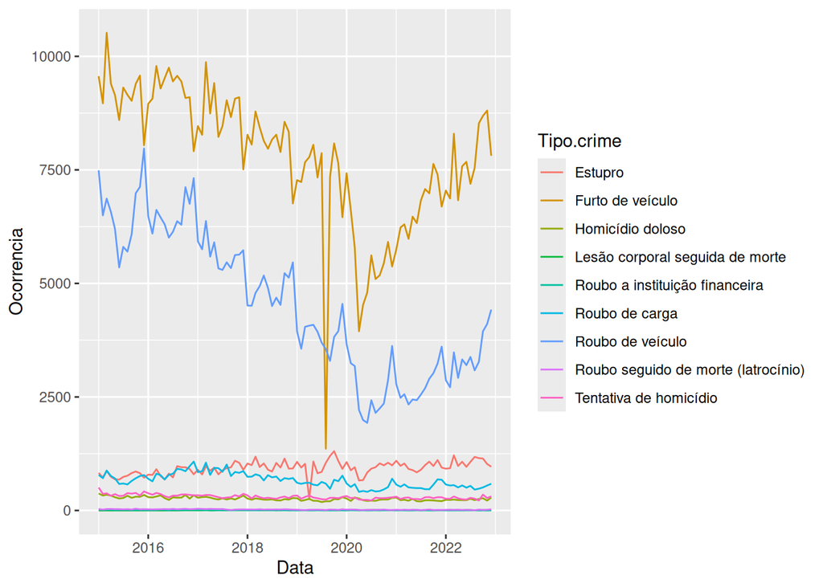

```r
crimes_mensal_sp_wide |>
  pivot_longer(
    cols=!c(Data),
    names_to = "Tipo.crime",
    values_to = "Ocorrencia"
  ) |>
  ggplot(aes(x = Data, y = Ocorrencia, color = `Tipo.crime`)) +
  geom_line()
```

Nota-se que furto e roubo de veiculos tem maiores valores, com sazonalidade mais aparente a primeira vista. Outros crimes tem valores mais constantes, sendo necessario visualizacao mais proxima

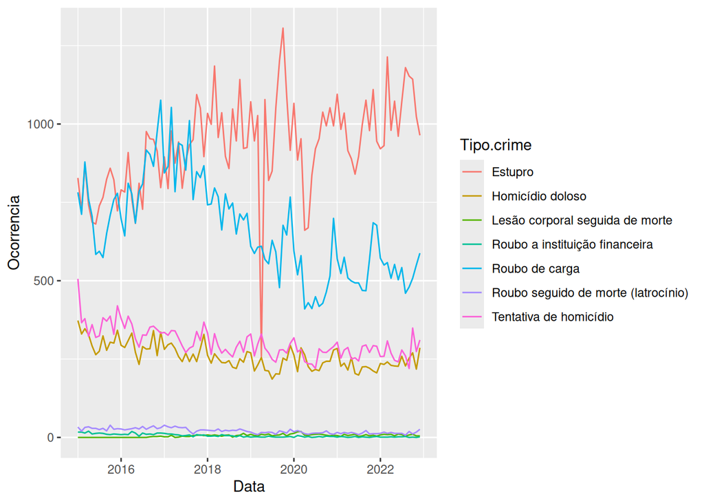

```r
crimes_mensal_sp_wide |>
  select(!c(`Roubo de veículo`, `Furto de veículo`)) |>
  pivot_longer(
    cols=!c(Data),
    names_to = "Tipo.crime",
    values_to = "Ocorrencia"
  ) |>
  ggplot(aes(x = Data, y = Ocorrencia, color = `Tipo.crime`)) +
  geom_line()
```

Observaremos primeiro a serie de Roubo de Veicuos

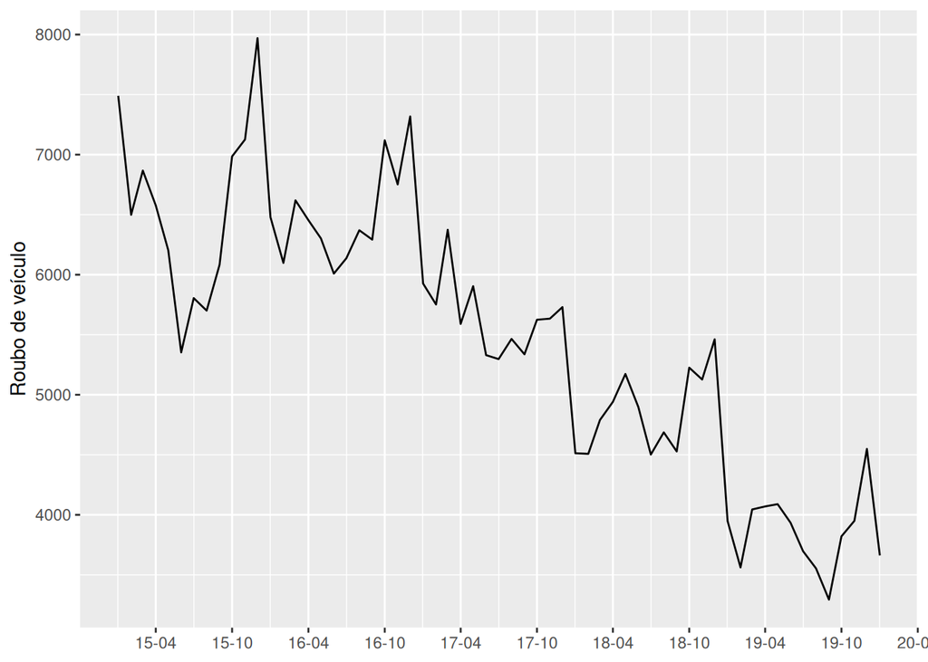

```r
crimes_mensal_sp_wide |>
  filter(Data >= "2015-01-01" & Data <= "2020-01-01") |>
  ggplot(aes(x = Data, y = `Roubo de veículo`))+
  geom_line() +
  scale_x_date(
    NULL,
    breaks = scales::breaks_width("6 month"),
    labels = scales::label_date("%y-%m")
  )
```

Aparenta-se que existe sazonalidade, observe picos proximos de outubro

## Analise geral de ACF e PACF

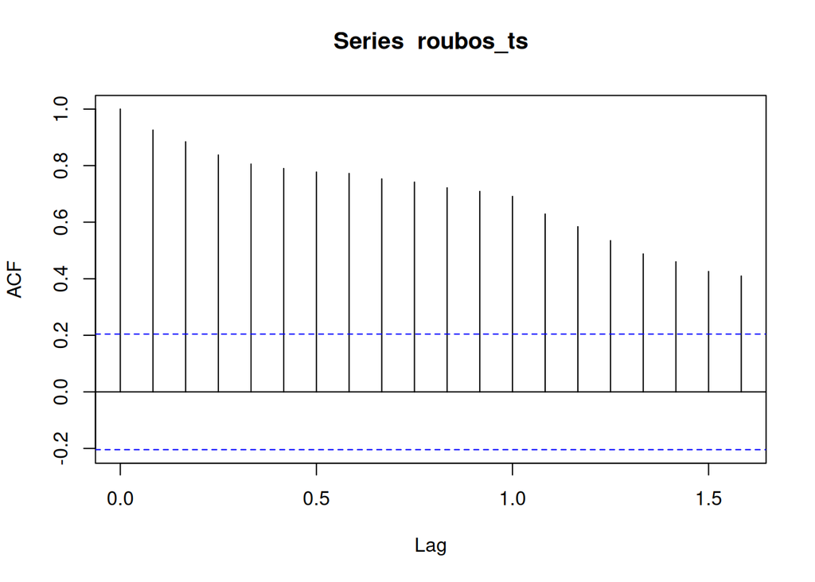

```r
roubos_ts <- crimes_mensal_sp_wide$`Roubo de veículo` |>
  ts(start = c(2015, 1), end = c(2022, 8), frequency = 12)
acf(roubos_ts)
```

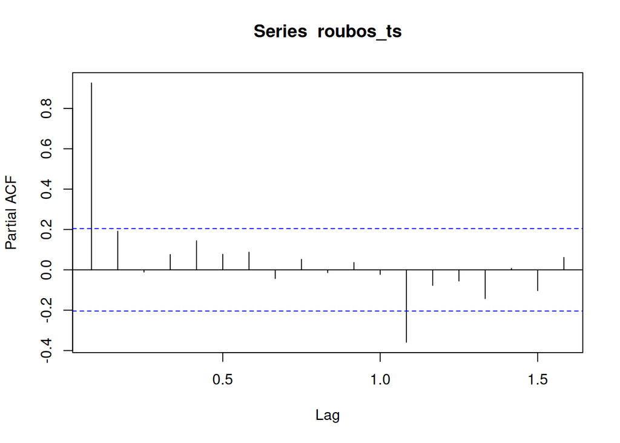

```r
pacf(roubos_ts)
```

Nota-se que a ACF possui valores que decaindo, e a PACF possui poucos picos, sendo um na marca de um ano, indicando sazonalidade.

## Ajuste com modelo de Holt-Winters

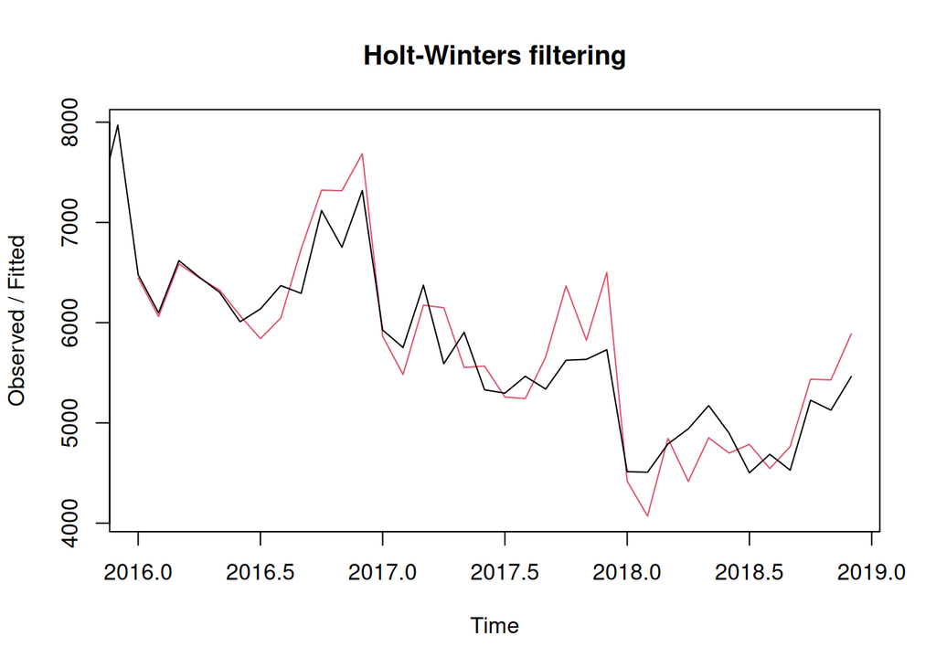

```r
# Separacao de treino e teste 2015-2020 de treino, 2021-2022 de teste

train.roubos_ts <- window(roubos_ts, start = c(2015, 1), end = c(2018, 12))
test.roubos_ts <- window(roubos_ts, start = c(2018, 12), end = c(2020, 2))
hw.fit <- HoltWinters(train.roubos_ts, seasonal = "additive")
plot(hw.fit)
```

```r
cat(sprintf("Holt-Winters ajustado\n"))
```

```
## Holt-Winters ajustado
```

```r
cat(sprintf("MSE = %f\n", hw.fit$SSE / length(train.roubos_ts)))
```

```
## MSE = 81873.859170
```

```r
cat(sprintf("alpha = %f\n", hw.fit$alpha))
```

```
## alpha = 0.782675
```

```r
cat(sprintf("beta = %f\n", hw.fit$beta))
```

```
## beta = 0.028840
```

```r
cat(sprintf("gama = %f\n", hw.fit$gamma))
```

```
## gama = 1.000000
```

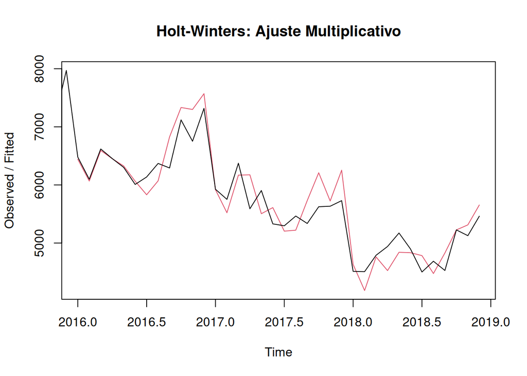

```r
hw.fit.mult <- HoltWinters(train.roubos_ts, seasonal = "multiplicative")
plot(hw.fit.mult, main = "Holt-Winters: Ajuste Multiplicativo")
```

```r
mse_mult <- hw.fit.mult$SSE / length(train.roubos_ts)
mse_add <- hw.fit$SSE / length(train.roubos_ts)

cat(sprintf("MSE Aditivo: %f\n", mse_add))
```

```
## MSE Aditivo: 81873.859170
```

```r
cat(sprintf("MSE Multiplicativo: %f\n", mse_mult))
```

```
## MSE Multiplicativo: 64585.941812
```

O Modelo Multiplicativo teve um error menor indicando que provavelmente a tendência e a sazonalidade possuem algum grau de proporcionalidade entre-si.

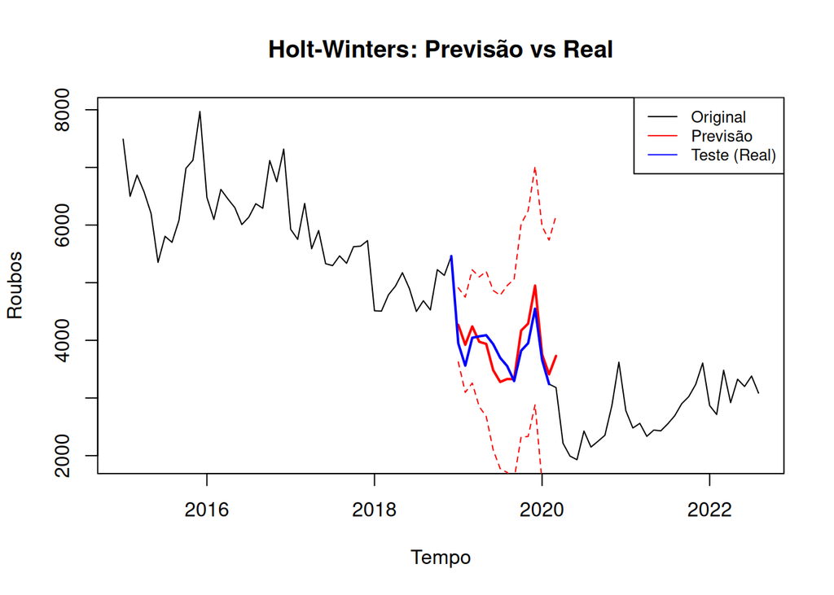

```r
modelo_final <- hw.fit

h <- length(test.roubos_ts)
previsao <- predict(modelo_final, n.ahead = h, prediction.interval = TRUE)

plot(roubos_ts, main = "Holt-Winters: Previsão vs Real", ylab = "Roubos", xlab = "Tempo")

lines(previsao[, "fit"], col = "red", lwd = 2)

lines(previsao[, "upr"], col = "red", lty = 2)
lines(previsao[, "lwr"], col = "red", lty = 2)

lines(test.roubos_ts, col = "blue", lwd = 2, lty = 1)

legend("topright", legend=c("Original", "Previsão", "Teste (Real)"),
       col=c("black", "red", "blue"), lty=1, cex=0.8)
```

```r
erro_teste <- test.roubos_ts - previsao[, "fit"]

rmse <- sqrt(mean(erro_teste^2))

mape <- mean(abs(erro_teste / test.roubos_ts)) * 100

cat(sprintf("RMSE (Erro Quadrático): %f\n", rmse))
```

```
## RMSE (Erro Quadrático): 289.096032
```

```r
cat(sprintf("MAPE (Erro Percentual): %.2f%%\n", mape))
```

```
## MAPE (Erro Percentual): 6.69%
```

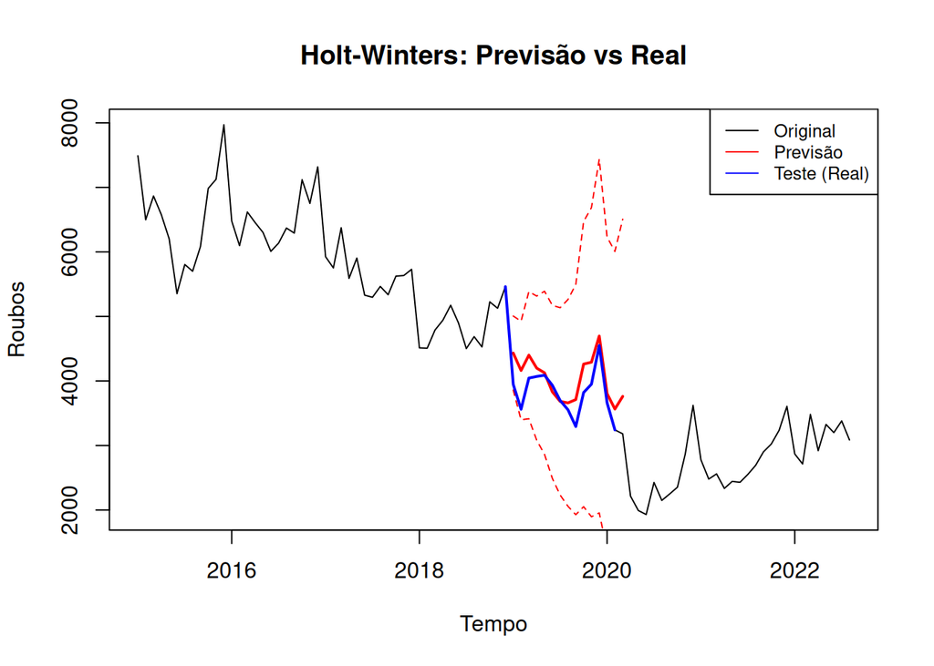

```r
modelo_final <- hw.fit.mult

h <- length(test.roubos_ts)
previsao <- predict(modelo_final, n.ahead = h, prediction.interval = TRUE)

plot(roubos_ts, main = "Holt-Winters: Previsão vs Real", ylab = "Roubos", xlab = "Tempo")

lines(previsao[, "fit"], col = "red", lwd = 2)

lines(previsao[, "upr"], col = "red", lty = 2)
lines(previsao[, "lwr"], col = "red", lty = 2)

lines(test.roubos_ts, col = "blue", lwd = 2, lty = 1)

legend("topright", legend=c("Original", "Previsão", "Teste (Real)"),
       col=c("black", "red", "blue"), lty=1, cex=0.8)
```

```r
erro_teste <- test.roubos_ts - previsao[, "fit"]

rmse <- sqrt(mean(erro_teste^2))

mape <- mean(abs(erro_teste / test.roubos_ts)) * 100

cat(sprintf("RMSE (Erro Quadrático): %f\n", rmse))
```

```
## RMSE (Erro Quadrático): 315.419765
```

```r
cat(sprintf("MAPE (Erro Percentual): %.2f%%\n", mape))
```

```
## MAPE (Erro Percentual): 6.99%
```

Com um erro de 6.69% o modelo aditivo e o multiplicativo com 6.99% tornam-se aceitaveis para modelar este evento que nao demanda precisão extrema.

```r
modelo_sarima <- auto.arima(train.roubos_ts, seasonal = TRUE,
                            stepwise = FALSE, approximation =
                              FALSE, trace = TRUE)
```

```
##
##  ARIMA(0,1,0)(0,1,0)[12]                    : 513.0737
##  ARIMA(0,1,0)(0,1,1)[12]                    : 513.2785
##  ARIMA(0,1,0)(1,1,0)[12]                    : 512.7921
##  ARIMA(0,1,0)(1,1,1)[12]                    : 514.8171
##  ARIMA(0,1,1)(0,1,0)[12]                    : 512.6967
##  ARIMA(0,1,1)(0,1,1)[12]                    : 513.9628
##  ARIMA(0,1,1)(1,1,0)[12]                    : 513.7012
##  ARIMA(0,1,1)(1,1,1)[12]                    : 515.9642
##  ARIMA(0,1,2)(0,1,0)[12]                    : 511.0217
##  ARIMA(0,1,2)(0,1,1)[12]                    : 513.2053
##  ARIMA(0,1,2)(1,1,0)[12]                    : 513.1979
##  ARIMA(0,1,2)(1,1,1)[12]                    : 515.9331
##  ARIMA(0,1,3)(0,1,0)[12]                    : 513.4308
##  ARIMA(0,1,3)(0,1,1)[12]                    : 515.933
##  ARIMA(0,1,3)(1,1,0)[12]                    : 515.9276
##  ARIMA(0,1,3)(1,1,1)[12]                    : 518.8588
##  ARIMA(0,1,4)(0,1,0)[12]                    : 516.1398
##  ARIMA(0,1,4)(0,1,1)[12]                    : 518.8578
##  ARIMA(0,1,4)(1,1,0)[12]                    : 518.8443
##  ARIMA(0,1,5)(0,1,0)[12]                    : 519.07
##  ARIMA(1,1,0)(0,1,0)[12]                    : 511.1238
##  ARIMA(1,1,0)(0,1,1)[12]                    : 513.014
##  ARIMA(1,1,0)(1,1,0)[12]                    : 512.9151
##  ARIMA(1,1,0)(1,1,1)[12]                    : 515.3165
##  ARIMA(1,1,1)(0,1,0)[12]                    : 512.4484
##  ARIMA(1,1,1)(0,1,1)[12]                    : 514.8269
##  ARIMA(1,1,1)(1,1,0)[12]                    : 514.814
##  ARIMA(1,1,1)(1,1,1)[12]                    : 517.5294
##  ARIMA(1,1,2)(0,1,0)[12]                    : 513.4127
##  ARIMA(1,1,2)(0,1,1)[12]                    : 515.9337
##  ARIMA(1,1,2)(1,1,0)[12]                    : 515.9284
##  ARIMA(1,1,2)(1,1,1)[12]                    : 518.8591
##  ARIMA(1,1,3)(0,1,0)[12]                    : Inf
##  ARIMA(1,1,3)(0,1,1)[12]                    : Inf
##  ARIMA(1,1,3)(1,1,0)[12]                    : Inf
##  ARIMA(1,1,4)(0,1,0)[12]                    : Inf
##  ARIMA(2,1,0)(0,1,0)[12]                    : 511.5562
##  ARIMA(2,1,0)(0,1,1)[12]                    : 514.0429
##  ARIMA(2,1,0)(1,1,0)[12]                    : 514.0448
```

[output cut: 11 more lines]

```
##  ARIMA(3,1,0)(1,1,0)[12]                    : 516.2826
##  ARIMA(3,1,0)(1,1,1)[12]                    : 519.2138
##  ARIMA(3,1,1)(0,1,0)[12]                    : 516.3792
##  ARIMA(3,1,1)(0,1,1)[12]                    : 519.1774
##  ARIMA(3,1,1)(1,1,0)[12]                    : 519.1744
##  ARIMA(3,1,2)(0,1,0)[12]                    : 519.0711
##  ARIMA(4,1,0)(0,1,0)[12]                    : 516.3099
##  ARIMA(4,1,0)(0,1,1)[12]                    : 519.0925
##  ARIMA(4,1,0)(1,1,0)[12]                    : 519.086
##  ARIMA(4,1,1)(0,1,0)[12]                    : Inf
##  ARIMA(5,1,0)(0,1,0)[12]                    : 518.7758
##
##
##
##  Best model: ARIMA(0,1,2)(0,1,0)[12]
```

```r
summary(modelo_sarima)
```

```
## Series: train.roubos_ts
## ARIMA(0,1,2)(0,1,0)[12]
##
## Coefficients:
##           ma1     ma2
##       -0.2619  0.3514
## s.e.   0.1628  0.1566
##
## sigma^2 = 111260:  log likelihood = -252.12
## AIC=510.25   AICc=511.02   BIC=514.91
##
## Training set error measures:
##                   ME     RMSE      MAE       MPE     MAPE      MASE        ACF1
## Training set 13.4679 276.5706 188.6416 0.2840901 3.360851 0.2771651 -0.01452139
```

p = 0 e q = 2, mostrando que foi detectado choques de curto prazo ao longo de 2 meses. e d = 1 pois foi necessaria uma diferenciação simples. D = 1 mostra que realmente deve haver uma sazonalidade anual. Q = 0, mostrando que apenas a diferenciação mês desse ano menos o mês do ano passado foi suficiente.

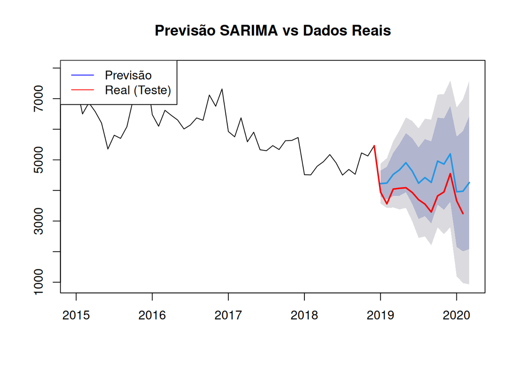

```r
h <- length(test.roubos_ts)
previsao_sarima <- forecast(modelo_sarima, h = h)

plot(previsao_sarima, main="Previsão SARIMA vs Dados Reais")
lines(test.roubos_ts, col="red", lwd=2)
legend("topleft", legend=c("Previsão", "Real (Teste)"), col=c("blue", "red"), lty=1)
```

```r
erro_sarima <- test.roubos_ts - previsao_sarima$mean
rmse_sarima <- sqrt(mean(erro_sarima^2))
mape_sarima <- mean(abs(erro_sarima / test.roubos_ts)) * 100

cat(sprintf("\nErro do SARIMA:\nRMSE: %f\nMAPE: %.2f%%\n", rmse_sarima, mape_sarima))
```

```
##
## Erro do SARIMA:
## RMSE: 728.576864
## MAPE: 18.32%
```

O melhor modelo foi o Holt-Winters Aditivo portanto iremos extrair os residuos do mesmo.

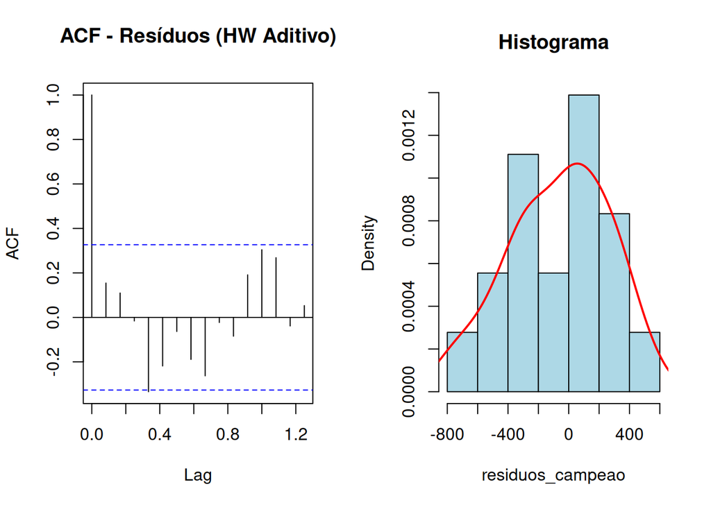

```r
residuos_campeao <- na.omit(residuals(hw.fit))


par(mfrow=c(1,2))

acf(residuos_campeao, main="ACF - Resíduos (HW Aditivo)")

hist(residuos_campeao, main="Histograma", col="lightblue", probability=TRUE)
lines(density(residuos_campeao), col="red", lwd=2)
```

```r
par(mfrow=c(1,1))


lb_test <- Box.test(residuos_campeao, type = "Ljung-Box")

cat(sprintf("\n--- RESULTADO FINAL (HW ADITIVO) ---\n"))
```

```
##
## --- RESULTADO FINAL (HW ADITIVO) ---
```

```r
cat(sprintf("MAPE (Teste): 6.69%%\n"))
```

```
## MAPE (Teste): 6.69%
```

```r
cat(sprintf("P-valor Ljung-Box: %.4f\n", lb_test$p.value))
```

```
## P-valor Ljung-Box: 0.3347
```

```r
if(lb_test$p.value > 0.05){
  cat("CONCLUSÃO: O modelo é ESTATISTICAMENTE VÁLIDO (Resíduos aleatórios).\n")
} else {
  cat("CONCLUSÃO: O modelo é o MELHOR PREDITOR, apesar de resíduos correlacionados.\n")
}
```

```
## CONCLUSÃO: O modelo é ESTATISTICAMENTE VÁLIDO (Resíduos aleatórios).
```

A análise comparativa indicou o método de Holt-Winters aditivo como o modelo mais adequado para a previsão da série de roubos. Após a remoção da quebra estrutural referente ao período da pandemia (2020-2021), o modelo demonstrou alta capacidade preditiva, apresentando um MAPE de 6.69% no conjunto de teste.